# Module 7 Project

R-ight-Angle

2023-11-05

## Introduction

The objective of this project was to investigate how the force-length relationship in muscles is affected by experimental condition, comparing non-fatigued (control) and fatigued data The aim was to determine if there was a significant alteration in the angle at which the maximum isometric force is generated, known as theta max. Previous research has shown a relationship between fatigued and a shift to the right in this angle, suggesting that fatigued muscles tend to exert more force at longer lengths (Biewener 2006). To further explore this association and validate this hypothesis, we collected and analyzed comprehensive data on maximum voluntary contractions from a class-wide sample, examining both fatigued and non-fatigued muscle conditions to understand whether our data set also exhibited a similar rightward shift.

## Methods

In order to assess the effect of eccentric fatigue of elbow flexor muscles we measured isometric force over the range of motion of the forearm produced by MVC. In order to obtain MVC data we designed and constructed a portable Arduino-based force-data acquisition system (DAQ).

1. DAQ Design components

100-kg S-type Load cell with HX711 amplifier

Arduino Uno microcontroller

2. Data Collection Elbow angle

Constructed a ganiometer. Then, found the center of the elbow joint in lateral view and marked this position with a marker. From that point, we marked a line along the lateral margin of the radius. We then poked a hole through the center of the ganiometer to affix it to the upper arm so that the center aligns with the mark at the elbow and the 0-180angle axis aligns with the long axis of the humerus.

3. Data Collection Isometric MVCs

Then, in order to use the ganiometer to collect isometric force data from MVCs over 12 arm angles, 45-157.5angles at 11.25angle intervals, we collected control (non-fatigued) data from the largest arm angle of 157.5. We moved through the 12 arm angles by rotating our bodies about the hips.

4. Data Collection MVCs after Eccentric Fatigue

To eccentrically fatigue our forearm flexors, we performed isokenetic controlled drops of a heavy weight object weighing 1/3 of our maximum isometric force recorded in the control experiment. We repeated the exercise for 3 minutes. Then, we waited 2 minutes before performing the experiment exactly the same as we did for the control data.

5. Data Analysis

From the data obtained with the Arduino setup, force analysis was conducted with R. Force was normalized according to experimental condition (fatigue vs. control), and the best-fitting polynomial model was assigned to each combination of participant, condition, and arm angle. Modeling allowed for calculation of a difference in theta max according to condition, termed the shift in theta max. Finally, this shift was analyzed in terms of its significance via ANOVA.

### Summary of Experimental Protocol

1. Fabricate and program a load-cell data acquisition system.
2. Make a ganiometer.
3. Record isometric MVCs at 12 distinct elbow angles. (un-fatigued data)
4. Eccentrically fatigue flexors.
5. Wait 2 minutes.
6. Repeat recording isometric MVCs at the same 12 distinct elbow angles (fatigued data)

## Results

Class data was altered to remove problematic groups that polynomials could not be fitted to (angles were of the same value). Additionally, force was normalized by condition. Polynomial models were generated to estimate maximum force, as the force-sarcomere length relationship is parabolic. Second, third, and fourth order polynomial models were assessed with the Akaike information criterion (AIC):

[output not shown]

```
##
##
## Table: Table 1: AIC scores for varying polynomial models
##         fitting control and fatigued data:
##
## |who        |activity |model |         AICc|
## |:----------|:--------|:-----|------------:|
## |Audrey     |control  |m2    |  -376.365589|
## |Audrey     |control  |m3    |  -375.612845|
## |Audrey     |control  |m4    |  -382.559103|
## |Audrey     |fatigue  |m2    |   115.398060|
## |Audrey     |fatigue  |m3    |   113.699932|
## |Audrey     |fatigue  |m4    |   115.177255|
## |Baylie     |control  |m2    |  -558.176705|
## |Baylie     |control  |m3    |  -626.899708|
## |Baylie     |control  |m4    |  -779.582585|
## |Baylie     |fatigue  |m2    |  -409.643400|
## |Baylie     |fatigue  |m3    |  -455.442116|
## |Baylie     |fatigue  |m4    |  -524.565948|
## |Jaan       |control  |m2    | -1348.332630|
## |Jaan       |control  |m3    | -1664.284227|
## |Jaan       |control  |m4    | -1698.001689|
## |Jaan       |fatigue  |m2    |  -954.477601|
## |Jaan       |fatigue  |m3    | -1042.353331|
## |Jaan       |fatigue  |m4    | -1042.658832|
## |Julia      |control  |m2    |  -758.701237|
## |Julia      |control  |m3    |  -938.397643|
## |Julia      |control  |m4    |  -951.668173|
## |Julia      |fatigue  |m2    |  -645.804270|
## |Julia      |fatigue  |m3    |  -724.990221|
## |Julia      |fatigue  |m4    |  -725.031387|
## |Lauren     |control  |m2    | -1584.321956|
## |Lauren     |control  |m3    | -1590.811044|
## |Lauren     |control  |m4    | -1650.996099|
## |Lauren     |fatigue  |m2    |   -24.679725|
## |Lauren     |fatigue  |m3    |   -39.658276|
## |Lauren     |fatigue  |m4    |   -38.791047|
## |Leo        |control  |m2    |  -720.558228|
## |Leo        |control  |m3    |  -759.575236|
## |Leo        |control  |m4    |  -804.176236|
```

[output cut: 105 more lines]

```
## |sean       |fatigue  |m2    |  -210.522858|
## |sean       |fatigue  |m3    |  -225.815399|
## |sean       |fatigue  |m4    |  -230.445686|
## |vanessa    |control  |m2    |  -356.327991|
## |vanessa    |control  |m3    |  -365.169974|
## |vanessa    |control  |m4    |  -570.312613|
## |vanessa    |fatigue  |m2    |  -107.265508|
## |vanessa    |fatigue  |m3    |  -105.642975|
## |vanessa    |fatigue  |m4    |  -111.875937|
## |yunshu     |control  |m2    |     6.457814|
## |yunshu     |control  |m3    |   -21.826106|
## |yunshu     |control  |m4    |   -19.827343|
## |yunshu     |fatigue  |m2    |  -401.439282|
## |yunshu     |fatigue  |m3    |  -468.364262|
## |yunshu     |fatigue  |m4    |  -577.655416|
```

Next, models were filtered by best fit to data (lowest AIC score):

```
## # A tibble: 51 × 5
## # Groups:   who, activity [51]
##    who    activity model theta_max    AICc
##    <chr>  <chr>    <chr>     <dbl>   <dbl>
##  1 Audrey control  m4        100.   -383.
##  2 Audrey fatigue  m3        118.    114.
##  3 Baylie control  m4         87.5  -780.
##  4 Baylie fatigue  m4        110.   -525.
##  5 Jaan   control  m4         83.4 -1698.
##  6 Jaan   fatigue  m4         93.1 -1043.
##  7 Julia  control  m4         86.1  -952.
##  8 Julia  fatigue  m4         96.7  -725.
##  9 Lauren control  m4        110.  -1651.
## 10 Lauren fatigue  m3        132.    -39.7
## # ℹ 41 more rows
```

Table 2: Best fitting model according to subject and condition, with predicted theta max value

| who | activity | model | theta_max | AICc |
| --- | --- | --- | --- | --- |
| Audrey | control | m4 | 99.95495 | -382.55910 |
| Audrey | fatigue | m3 | 118.19820 | 113.69993 |
| Baylie | control | m4 | 87.45495 | -779.58258 |
| Baylie | fatigue | m4 | 109.52703 | -524.56595 |
| Jaan | control | m4 | 83.40090 | -1698.00169 |
| Jaan | fatigue | m4 | 93.08559 | -1042.65883 |
| Julia | control | m4 | 86.10360 | -951.66817 |
| Julia | fatigue | m4 | 96.68919 | -725.03139 |
| Lauren | control | m4 | 109.52703 | -1650.99610 |
| Lauren | fatigue | m3 | 132.38739 | -39.65828 |
| Leo | control | m4 | 92.40991 | -804.17624 |
| Leo | fatigue | m3 | 98.71622 | -366.98641 |
| Susanne | control | m3 | 77.54505 | -964.72383 |
| Susanne | fatigue | m4 | 157.50000 | -593.47309 |
| Tara | control | m4 | 87.56757 | -934.31031 |
| Tara | fatigue | m3 | 126.30631 | -602.36697 |
| alex | control | m4 | 95.45045 | -532.80020 |
| alex | fatigue | m4 | 107.72523 | -585.70371 |
| ana | control | m4 | 103.67117 | -977.06284 |
| ana | fatigue | m4 | 45.00000 | -55.61746 |
| andrew | control | m4 | 96.46396 | -524.66318 |
| andrew | fatigue | m4 | 110.87838 | -356.47957 |
| ben | control | m4 | 96.12613 | -2016.35692 |
| ben | fatigue | m4 | 105.92342 | -1596.58512 |
| conor | control | m3 | 116.39640 | -415.39930 |
| conor | fatigue | m4 | 157.50000 | -351.73117 |
| elisabeth | control | m4 | 98.26577 | -3931.21843 |
| elisabeth | fatigue | m4 | 146.68919 | -2192.05533 |
| elizabeth | control | m4 | 89.03153 | -366.54827 |
| elizabeth | fatigue | m4 | 102.88288 | -195.78231 |
| georgia | control | m4 | 89.70721 | -875.99537 |
| georgia | fatigue | m4 | 114.14414 | -396.51872 |
| hannah | control | m4 | 97.81532 | -502.79531 |
| hannah | fatigue | m4 | 108.28829 | -307.31837 |
| jess | control | m4 | 88.91892 | -2820.69434 |
| jess | fatigue | m4 | 45.00000 | -1303.66811 |
| jonah | control | m4 | 56.93694 | -984.29263 |
| jonah | fatigue | m3 | 97.92793 | -745.20491 |
| katie | control | m4 | 104.79730 | -1495.47387 |
| katie | fatigue | m4 | 107.27477 | -739.94975 |
| letacianna | control | m4 | 93.87387 | -1790.28878 |
| michael | control | m4 | 97.02703 | -3558.83503 |
| michael | fatigue | m4 | 84.30180 | -2829.90169 |
| nicole | control | m4 | 98.37838 | -605.62968 |
| nicole | fatigue | m4 | 126.98198 | -443.22225 |
| sean | control | m4 | 92.97297 | -1506.37360 |
| sean | fatigue | m4 | 92.07207 | -230.44569 |
| vanessa | control | m4 | 104.34685 | -570.31261 |
| vanessa | fatigue | m4 | 101.19369 | -111.87594 |
| yunshu | control | m3 | 124.16667 | -21.82611 |
| yunshu | fatigue | m4 | 157.50000 | -577.65542 |

Finally, an ANOVA test was run to investigate a shift in theta max between experimental conditions (control and fatigued). A significant difference in theta max between conditions was found, with a p-value for the F statistic of 0.01981. The mean shift and standard error of the mean were found to be:

```
## Analysis of Variance Table
##
## Response: theta_max
##           Df  Sum Sq Mean Sq F value  Pr(>F)
## activity   1  2796.5 2796.49  5.8026 0.01981 *
## Residuals 49 23614.9  481.94
## ---
## Signif. codes:  0 '***' 0.001 '**' 0.01 '*' 0.05 '.' 0.1 ' ' 1
```

```
##
##
## Table: Table 3: Mean shift in theta max
##
## | mean.shift| se.shift|
## |----------:|--------:|
## |   14.77027| 5.455925|
```

To visualize the shift in maximum angle, the grouped bar plot of Figure 1 was generated:

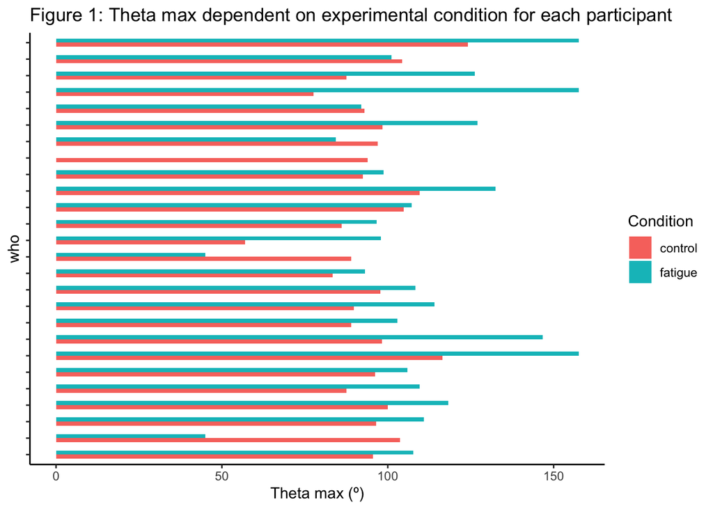

## Discussion

Our group was assigned the task to examine the force-length relationship property in skeletal muscles, focusing on the forearm flexor muscles. The force-length relationship concept revolves around muscles exerting maximum force at their resting length and decreasing force when either shortened or stretched beyond that point. Our project specifically investigated how fatigue influences the force-length relationship in the upper limbs.

Upon analyzing the collective data set from our class, we identified a significant mean shift of approximately 14.7 degrees in the maximum force-producing angles between fatigue and control measurements. Utilizing ANOVA variance testing, we observed a noteworthy upward shift from controlled to fatigued muscles, reaching statistical significance at the 5% level. Therefore, the insights gained from our class’s studies contribute to the advancement of understanding upper arm biomechanics.

In one study analyzing mechanically isolated sacromeres, it was concluded that while sacromere forces are strongly influenced by sacromere lengths under isometric conditions, they can exhibit various steady-state values depending on the sacromere’s contractile history (Herzog 2022). The study also investigated force enhancements in individual sacromeres, suggesting that the force-dependent attachment of titin to actin could shorten the sacromere’s resting spring length, thereby increasing its stiffness. Perhaps, by exploring the role of regulatory proteins in muscle contraction, such as troponin and tropomyosin, we can gain better understanding into force depression within sacromeres, particularly their impact on cross-bridge attachments to actin. Furthermore, examining the influence of a sacromere’s contractile history during eccentric forces on non-isolated sacromeres could provide interesting and valuable information.

## Author Contributions

Susanne Hahs: Introduction, Discussion, Bibliography.

Julia Curry: Wrote the Methods and contributed to editing. Set up Arduino board.

Binghao Deng: data collection, file formatting, and final code review

Jaan Selod: Wrote results section, part 5 of methods, and helped set up Arduino + reread.

## References

Biewener, Andrew A. 2006. “Tired of Fatigue? Factors Affecting the Force-Length Relationship of Muscle.” *Journal of Applied Physiology*.

Herzog, Walter. 2022. “What Can We Learn from Single Sacromere and Myofibril Preparations?” *Frontiers in Physiology*.